# Et muligt udfald

Silas Furu Friby  
28 aug 2018

### Program

- Hvem *er* jeg?
- Hvem *var* jeg?
- Tiden på MatØk studiet
  - Tillishverv
  - Studiejobs
- Erhvervs-karriere
- Erfaringer fra den *virkelige* verden
- Simulations-projekt: teori, arbejde og bachelorprojekt

### Hvem er jeg?

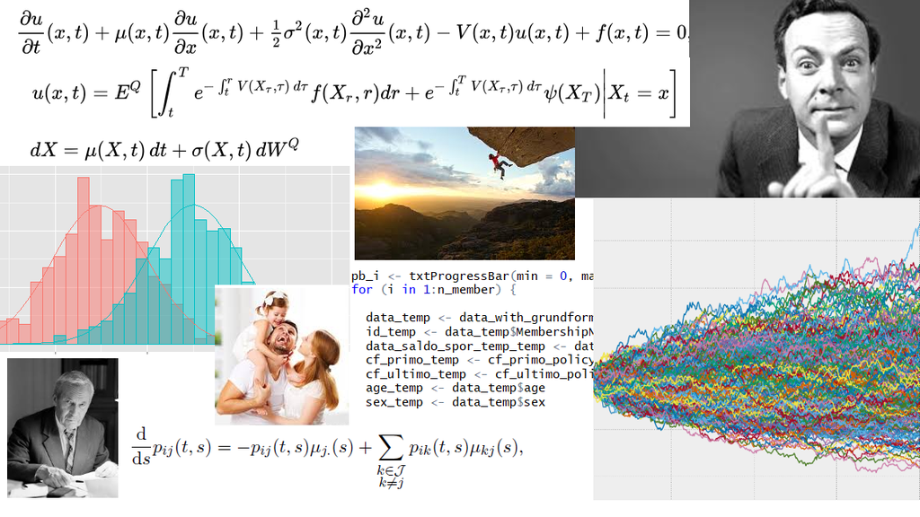

### Hvem var jeg?

- 20 år gammel på en strand i Malaysia med en god kammerat i 2008
- Jeg kunne godt lide matematik (det er en nødvendighed)
- Lidt rodet start
  - Troede jeg skulle læse ved vor frue plads - historiske gamle bygninger - realiteten: beton på ydre nørrebro
  - Glemte at melde mig til rusturen (meeeeeen jeg kom heldigvis med alligevel)

### Tiden på MatØk studiet - tillidshverv

- Rusvejleder. Fantastisk sjovt - ikke hårdt arbejde (i hvert fald ikke for mit vedkommende)
- Formand for MatØk bestyrelsen (festudvalget) - fantastisk sjovt, men lidt hårdt til oprydningerne

### Tiden på MatØk studiet - studiejobs

- Instruktor på KU. B.l.a. i *ØkIntro*, *LinAlg* og *Mikro1* som I skal have på 1. og 2. år
  - Kan klart anbefales hvis man har mod på det! Lærerigt og gode socialerelationer på tværs af årgangene
- Studentermedhjælper hos Finanstilsynet
  - Lidt kedeligt. Men lærte Excel
- Forskningsassistent på Center for Financial Frictions på CBS
  - Troede at jeg ville læse en Ph.D.
  - Lærte at man altid skal gå kritisk til værks

### Erhvervs-karriere

- 2015 - 2017: Konsulent hos Deloitte
- 2017 - 2018: Konsulent hos KPMG
- 2018: Bachelorvejleder på Københavns Universitet
- 2018 -: Aktuar hos Norli Pension

### Konsulent hos Deloitte

- Kortere projekter. Nogle meget interessante, nogle meget uinteressante
- Stjel læringskurve
- Nordea, Pension Danmark, SEB, Asseco, Forca, Storebrand, DSV, m.m
- Giver et bredt netværk

### Konsulent hos Deloitte

Blev opsagt/fyret i sommeren 2017. Årsager:

- Nedskæringer, 20 procent af afdeling blev fjernet
- Jeg havde været væk i 5 måneder (klatretur)
- Afholdte 52 ugers ferie på lidt over to år
- Kendt i Deloitte som “ham i t-shirt”
- Sagde nej til kedelige opgaver

Ikke en sjov oplevelse, men forståeligt…

### Arbejdsløs

Arbejdsløs i Sydfrankrig.. hva så nu?

Er det svært at finde nyt job?

### Arbejdsløs

- Svaret er NEJ!
- Let at få job i et kapitalistisk samfund, hvis man godt kan lide matematik, statistik og programmering
- MatØk'ere er urimeligt priviligeret på jobmarkedet
- Eksempel: takkede nej til flere jobsamtaler
- Fik nyt job som konsulent hos KPMG, mens jeg klatrede rundt i Italien

### Norli Pension

- “Start-up” pensionsselskab med en god business case
- Modsat konsulent verdenen kan jeg virkelig fordybe mig
- Kan også være frustrende. Har brugt en stor del af de sidste 6 måneder på samme projekt
- Opkøb af pensionsbestande. Meget spændende opgave, da der ikke findes et egentlig marked

### Bachelorvejleder på KU

- Savner universitet
- Vejledte 5 individuelle BA projekter i foråret
- Virkelig hyggeligt! Men også lidt mere tidskrævende end forventet
- Vender tilbage til projektet på senere slides

### Erfaringer fra den virkelige verden

- Universitet er et fitness center for hjernen - det at kunne lære hurtigt
- Programmeringskundskaber. Uden tvivl noget af det vigtigste og mest værdsatte på jobmarkedet! Vær ikke skræmt - jeg var ingen computernørd da jeg startede i sin tid - MEN lær det!
- At omsætte teori til tal
- R, Python, C#, C++, F#, SQL, VBA, Git
- Sociale kompetenser. Hvis man vil frem i verden er det en god ide at kunne omgås andre mennesker
- Intuition! Forståelse, ikke udenadslære!
- Regnskab og virksomhedsforståelse
- Machine Learning, AI - skal vi være bekymret?

### Next up: Simulating reality